# Homework 5 (Computational)

# Instuctions

Name:

Collaborated with:

**This homework is due on Feb. 16th at 11:55 pm.** You can collaborate with your classmates, but you must identify their names above, and you must submit **your own** homework as knitted HTML/PDF file to Canvas

Instruction: fill your answers in the `.Rmd`, compile it to HTML/PDF and submit the complied file. Uncompiled `.Rmd` file will not be graded.

Total score of this HM is:

# 1 Model Selection

## 1.1 Model Selection (I) (Total score: 25)

### 1.1.1 (a) [2 points] Use the `rnorm` function to generate a predictor $\bf{X}$ of length $n = 100$, as well as a noise vector $\bf{\epsilon}$ of length $n = 100$. Do not print the entire vector, just the code you would use to obtain the above.

```r
set.seed(100)
X=rnorm(100)
noise_vec=rnorm(100)
```

### 1.1.2 (b) [3 points] Generate a response vector $\bf{Y}$ of length $n = 100$ according to the model $$Y = \beta_0 + \beta_1 X + \beta_2 X^2 + \beta_3 X^3 + \epsilon,$$ where $\beta_0 = 3$, $\beta_1 = 2$, $\beta_2 = -3$, $\beta_3 = 0.3$. Do not print the entire vector, just the code you would use to obtain the above.

```r
Y=3+2*X-3*X^2+0.3*X^3+noise_vec
```

### 1.1.3 (c) [5 points] Use the `regsubsets` function from `leaps` package to perform best subset selection in order to choose the best model containing the predictors $(X, X^2, \cdots, X^{10})$. What is the best model obtained according to $C_p$, BIC, and adjusted $R^2$? Show some plots to provide evidence for your answer, and report the coefficients of the best model obtained.

```r
require(leaps)
require(tidyverse);
```

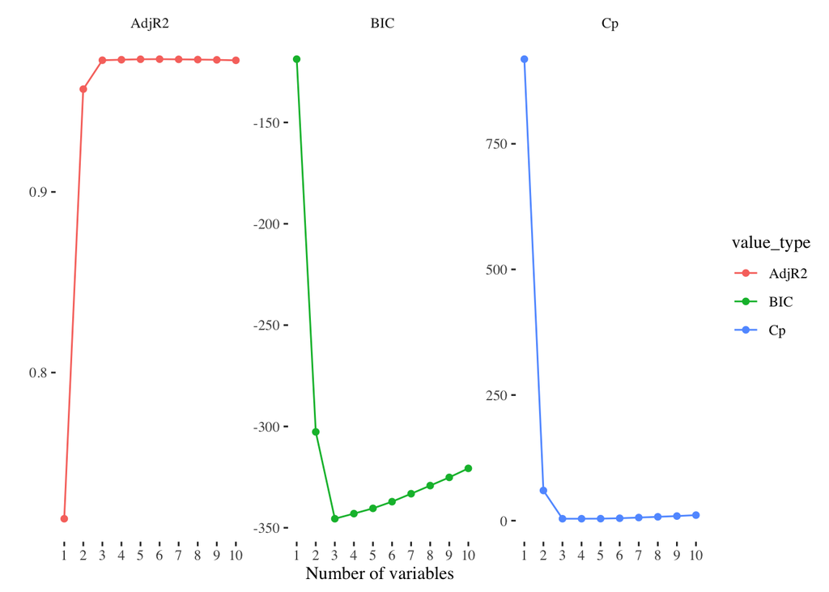

```r
require(ggplot2);
require(ggthemes);
df <- data.frame(Y, X)
fit <- regsubsets(Y ~ poly(X, 10), data = df, nvmax = 10)

fit_summary <- summary(fit)

data_frame(Cp = fit_summary$cp,
           BIC = fit_summary$bic,
           AdjR2 = fit_summary$adjr2) %>%
    mutate(id = row_number()) %>%
    gather(value_type, value, -id) %>%
    ggplot(aes(id, value, col = value_type)) +
    geom_line() + geom_point() + ylab('') + xlab('Number of variables') +
    facet_wrap(~ value_type, scales = 'free') +
    theme_tufte() + scale_x_continuous(breaks = 1:10)
```

```r
coefficients(fit, id=3)
```

```
##  (Intercept) poly(X, 10)1 poly(X, 10)2 poly(X, 10)3
##  -0.02235944  23.26508688 -40.70118584   6.04999560
```

### 1.1.4 (d) [5 points] Repeat (c), using forward stepwise selection and also using backwards stepwise selection. How does your answer compare to the results in (c)? You must show a summary of the selected model or other evidence to support your statements.

```r
library(caret)
back <- train(Y ~ poly(X, 10), data = df,
               direction = 'backward',   method = 'glmStepAIC',
                    trace = 0,
               trControl = trainControl(method = 'none', verboseIter = FALSE))

postResample(predict(back, df), df$Y)
```

```
##      RMSE  Rsquared       MAE
## 0.7606471 0.9747864 0.6106549
```

```r
summary(back$finalModel)
```

```
##
## Call:
## NULL
##
## Deviance Residuals:
##      Min        1Q    Median        3Q       Max
## -1.99337  -0.44408  -0.02266   0.54924   1.74333
##
## Coefficients:
##                 Estimate Std. Error t value Pr(>|t|)
## (Intercept)     -0.02236    0.07845  -0.285    0.776
## `poly(X, 10)1`  23.26509    0.78455  29.654  < 2e-16 ***
## `poly(X, 10)2` -40.70119    0.78455 -51.879  < 2e-16 ***
## `poly(X, 10)3`   6.05000    0.78455   7.711 1.28e-11 ***
## `poly(X, 10)4`   1.11467    0.78455   1.421    0.159
## `poly(X, 10)8`  -1.08391    0.78455  -1.382    0.170
## ---
## Signif. codes:  0 '***' 0.001 '**' 0.01 '*' 0.05 '.' 0.1 ' ' 1
##
## (Dispersion parameter for gaussian family taken to be 0.6155149)
##
##     Null deviance: 2294.729  on 99  degrees of freedom
## Residual deviance:   57.858  on 94  degrees of freedom
## AIC: 243.07
##
## Number of Fisher Scoring iterations: 2
```

```r
x_poly <- poly(df$X, 10)

colnames(x_poly) <- paste0('poly', 1:10)
forward <- train(y = Y, x = x_poly,
                    method = 'glmStepAIC', direction = 'forward',
                    trace = 0,
               trControl = trainControl(method = 'none', verboseIter = FALSE))

postResample(predict(forward, data.frame(x_poly)), df$Y)
```

```
##      RMSE  Rsquared       MAE
## 0.7606471 0.9747864 0.6106549
```

```r
summary(forward$finalModel)
```

```
##
## Call:
## NULL
##
## Deviance Residuals:
##      Min        1Q    Median        3Q       Max
## -1.99337  -0.44408  -0.02266   0.54924   1.74333
##
## Coefficients:
##              Estimate Std. Error t value Pr(>|t|)
## (Intercept)  -0.02236    0.07845  -0.285    0.776
## poly2       -40.70119    0.78455 -51.879  < 2e-16 ***
## poly1        23.26509    0.78455  29.654  < 2e-16 ***
## poly3         6.05000    0.78455   7.711 1.28e-11 ***
## poly4         1.11467    0.78455   1.421    0.159
## poly8        -1.08391    0.78455  -1.382    0.170
## ---
## Signif. codes:  0 '***' 0.001 '**' 0.01 '*' 0.05 '.' 0.1 ' ' 1
##
## (Dispersion parameter for gaussian family taken to be 0.6155149)
##
##     Null deviance: 2294.729  on 99  degrees of freedom
## Residual deviance:   57.858  on 94  degrees of freedom
## AIC: 243.07
##
## Number of Fisher Scoring iterations: 2
```

### 1.1.5 (e) [5 points] Now fit a LASSO model with `glmnet` function from `glmnet` package to the simulated data, again using $(X,X^2,\cdots,X^{10})$ as predictors. Use 5-fold cross-validation to select the optimal value of $\lambda$. Create plots of the cross-validation error as a function of $\lambda$. Report the resulting coefficient estimates, and discuss the results obtained.

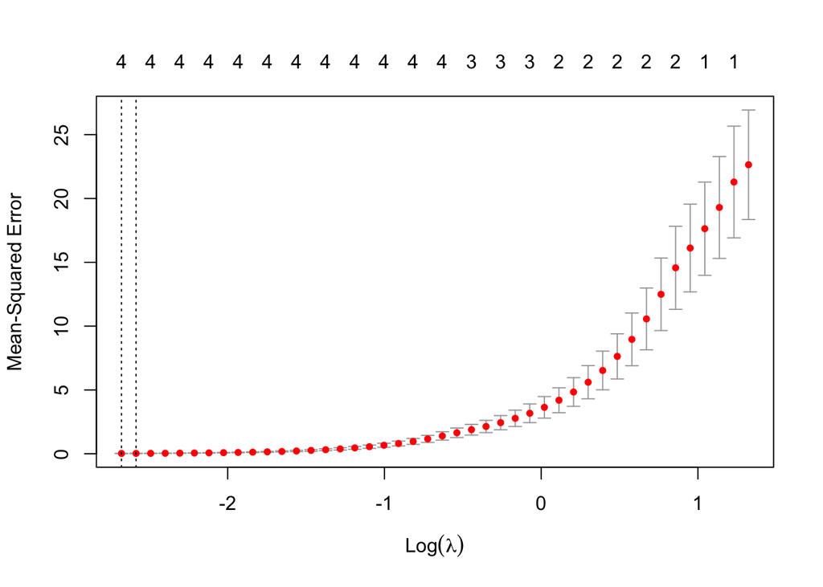

```r
matrix_x=as.matrix(data.frame(X,X2=X^2,X3=X^3,X4=X^4,X5=X^5,X6=X^6,X7=X^7,X8=X^8,X9=X^9,X10=X^10,noise_vec),ncol=11)
cv.out <- cv.glmnet(matrix_x,Y,alpha=1,nfolds=5)
plot(cv.out)
```

```r
cat("Lambda with smallest CV Error",
cv.out$lambda[which.min(cv.out$cvm)],fill=TRUE)
```

```
## Lambda with smallest CV Error 0.06873642
```

```r
model=glmnet(matrix_x,Y,alpha=1,lambda=cv.out$lambda[which.min(cv.out$cvm)])
coef(model)
```

```
## 12 x 1 sparse Matrix of class "dgCMatrix"
##                     s0
## (Intercept)  2.9340409
## X            1.9681273
## X2          -2.9313291
## X3           0.2807988
## X4           .
## X5           .
## X6           .
## X7           .
## X8           .
## X9           .
## X10          .
## noise_vec    0.8870738
```

```r
cat("Number of Zero Coefficients",
sum(abs(coef(model))<1e-8),fill=TRUE)
```

```
## Number of Zero Coefficients 7
```

## 1.2 Model Selection (II)

### 1.2.1 (f) [5 points] Now generate a response vector $Y$ according to the model $$Y = \beta_0 + \beta_7 X^7 + \epsilon,$$ where $\beta_7 = 7$, and perform best subset selection and the LASSO. Discuss the results obtained.

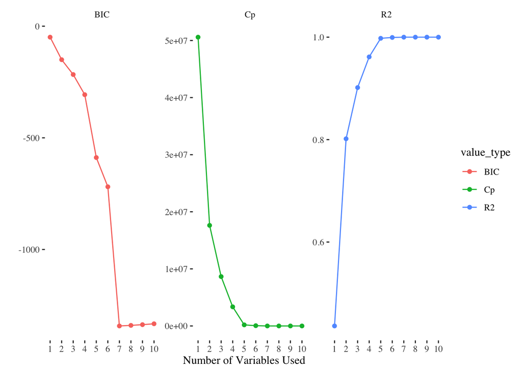

```r
Y_new=3+7*X^7+noise_vec

df_2 <- data_frame(Y_new = Y_new, X = df[,-1])

fit <- regsubsets(Y_new ~ poly(X, 10), data = df_2, nvmax = 10)

fit_summary <- summary(fit)

data_frame(Cp = fit_summary$cp,
           BIC = fit_summary$bic,
           R2 = fit_summary$adjr2) %>%
    mutate(id = row_number()) %>%
    gather(value_type, value, -id) %>%
    ggplot(aes(id, value, col = value_type)) +
    geom_line() + geom_point() + ylab('') + xlab('Number of Variables Used') +
    facet_wrap(~ value_type, scales = 'free') +
    theme_tufte() + scale_x_continuous(breaks = 1:10)
```

```r
coefficients(fit, id=7)
```

```
##  (Intercept) poly(X, 10)1 poly(X, 10)2 poly(X, 10)3 poly(X, 10)4 poly(X, 10)5
##     74.20383   4553.98811   2374.99585   5019.39596   1409.88214   1825.44872
## poly(X, 10)6 poly(X, 10)7
##    176.16393    299.07817
```

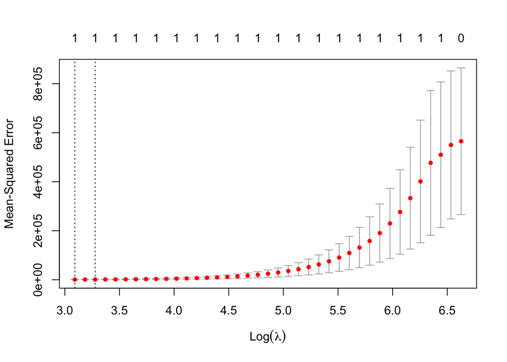

```r
matrix_x=as.matrix(data.frame(X,X2=X^2,X3=X^3,X4=X^4,X5=X^5,X6=X^6,X7=X^7,X8=X^8,X9=X^9,X10=X^10,noise_vec),ncol=11)
cv.out <- cv.glmnet(matrix_x,Y_new,alpha=1,nfolds=5)
plot(cv.out)
```

```r
cat("Lambda with smallest CV Error",
cv.out$lambda[which.min(cv.out$cvm)],fill=TRUE)
```

```
## Lambda with smallest CV Error 22.01092
```

```r
model=glmnet(matrix_x,Y_new,alpha=1,lambda=cv.out$lambda[which.min(cv.out$cvm)])
coef(model)
```

```
## 12 x 1 sparse Matrix of class "dgCMatrix"
##                      s0
## (Intercept) 5.084071268
## X           .
## X2          .
## X3          .
## X4          .
## X5          .
## X6          .
## X7          6.781796375
## X8          .
## X9          0.002065034
## X10         .
## noise_vec   .
```

```r
cat("Number of Zero Coefficients",
sum(abs(coef(model))<1e-8),fill=TRUE)
```

```
## Number of Zero Coefficients 9
```

# 2 Prediction

In this exercise, we will try to develop a prediction model for wins in a basketball season for a team based on a host of other factors. The starting point is to load the nba-teams-2017 data set (which was scraped by Gaston Sanchez at Berkeley). This is in the same folder as this Rmd file.

## 2.1 Prediction (I) (Total score: 10)

### 2.1.1 (a) [8 points] Do some exploratory data analysis by picking 6-7 features that you think might be interesting and explore relationship between these features by making a scatterplot matrix like the **scatterplot.pdf** or **rplot.jpg** file in the HW3 folder.

```r
library(ggplot2)
library(GGally)
bball_data <- read.csv('nba-teams-2017.csv')
head(bball_data)
```

```
##                    team games_played wins losses win_prop minutes points
## 1 Golden State Warriors           82   67     15    0.817    48.2  115.9
## 2     San Antonio Spurs           82   61     21    0.744    48.3  105.3
## 3       Houston Rockets           82   55     27    0.671    48.2  115.3
## 4        Boston Celtics           82   53     29    0.646    48.2  108.0
## 5             Utah Jazz           82   51     31    0.622    48.2  100.7
## 6       Toronto Raptors           82   51     31    0.622    48.2  106.9
##   field_goals field_goals_attempted field_goals_prop points3 points3_attempted
## 1        43.1                  87.1             49.5    12.0              31.2
## 2        39.3                  83.7             46.9     9.2              23.5
## 3        40.3                  87.2             46.2    14.4              40.3
## 4        38.6                  85.1             45.4    12.0              33.4
## 5        37.0                  79.5             46.6     9.6              26.0
## 6        39.2                  84.4             46.4     8.8              24.3
##   points3_prop free_throws free_throws_att free_throws_prop off_rebounds
```

[output cut: 20 more lines]

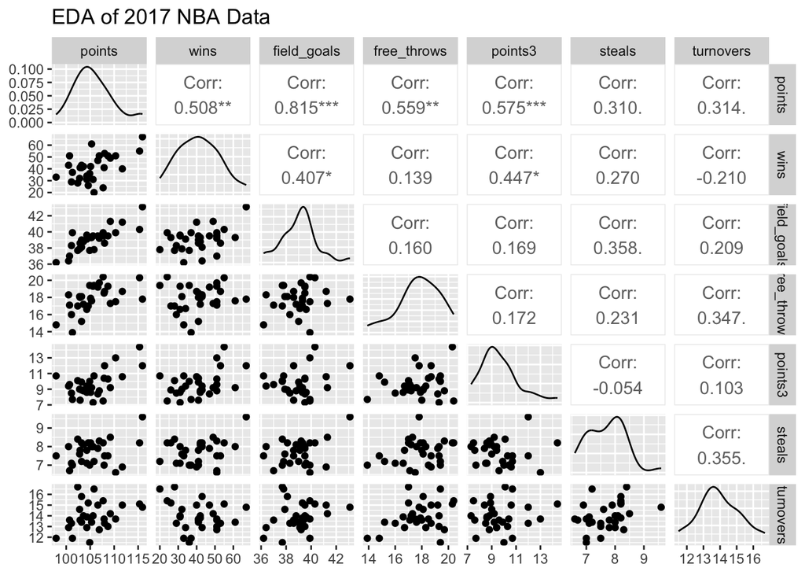

```r
bball_data2=bball_data[,c("points","wins","field_goals","free_throws","points3","steals","turnovers")]
ggpairs(bball_data2) +
  ggtitle("EDA of 2017 NBA Data")
```

### 2.1.2 (b)[2 points] The aim is now to predict *wins* based on the other features. First explain why you would remove the “losses” column from the above data set? Would you necessarily remove any other columns?

The reason I remove losses because losses is directly correlated with wins by using 82-wins. We can not uses losses to explore the relationship with wins. I would also remove column like games_played cuz every team is the same 82 and the variable team cuz it’s not numerical.

## 2.2 Prediction (II) (Total score: 10)

### 2.2.1 (c) [5 points] Use ridge regression with 5 fold cross-validation to choose the optimal tuning parameter and report your model along with your test error as found by cross-validation for that choice of $\lambda$.

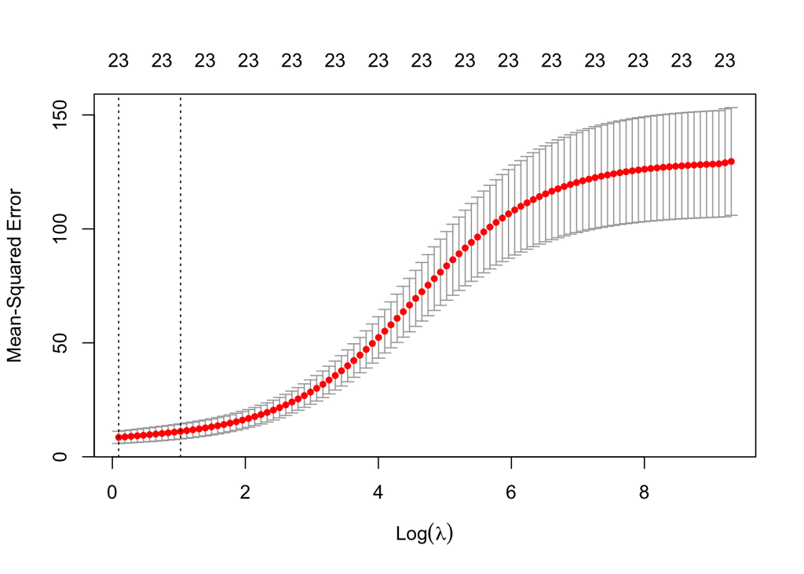

```r
y=bball_data$wins
x=data.matrix(bball_data[,!(names(bball_data)%in%c("games_played","team","wins","losses"))])
cv.out=cv.glmnet(x,y,nfold=5,alpha=0)

plot(cv.out)
```

```r
cat("Lambda with smallest CV Error",
cv.out$lambda[which.min(cv.out$cvm)],fill=TRUE)
```

```
## Lambda with smallest CV Error 1.099998
```

### 2.2.2 (d) [5 points] Fit a LASSO model on the training set, with $\lambda$ chosen by 5-fold cross-validation. Report the test error obtained, along with the number of non-zero coefficient estimates.

```r
cv_lasso=cv.glmnet(x,y,nfold=5,alpha=1)
best_model=glmnet(x,y,alpha=1,lambda=cv_lasso$lambda[which.min(cv_lasso$cvm)])
coef(best_model)
```

```
## 24 x 1 sparse Matrix of class "dgCMatrix"
##                              s0
## (Intercept)            1.200385
## win_prop              79.604537
## minutes                .
## points                 .
## field_goals            .
## field_goals_attempted  .
## field_goals_prop       .
## points3                .
## points3_attempted      .
## points3_prop           .
## free_throws            .
## free_throws_att        .
## free_throws_prop       .
## off_rebounds           .
## def_rebounds           .
## rebounds               .
## assists                .
## turnovers              .
## steals                 .
## blocks                 .
## block_fga              .
## personal_fouls         .
## personal_fouls_drawn   .
## plus_minus             .
```

```r
cat("Number of non-Zero Coefficients",
sum(abs(coef(best_model))>1e-8),fill=TRUE)
```

```
## Number of non-Zero Coefficients 2
```

```r
best_lambda=cv.out$lambda[which.min(cv.out$cvm)]
y_predicted <- predict(best_model, s = best_lambda, newx = x)
mse=mean((y_predicted-y)^2)
cat("The training error of this model is ", mse)
```

```
## The training error of this model is  0.1032019
```

# 3 High-Dimension Experiment (Sparse)

Let us now try to understand the performance of the various techniques on simulated data to get insight. Suppose your true model is $\mathbf{y}=\mathbf{X\beta} + \mathbf{\epsilon}$ where:

- Sparse coefficient vector $\mathbf{\beta}=(\underbrace{1,...,1}_{20}, \underbrace{0,...,0}_{1980})^T$;
- $p=2000 > n=1000$;
- Uncorrelated predictors: $\mathbf{X}_i \overset{\text{iid}}{\sim} N(\mathbf{0}, \mathbf{I})$. Precisely for the $i$-th individual, $\mathbf{X}_i = (X_{i1}, X_{i2}, \ldots, X_{i,2000})$ where $X_{i,j}$ are independent and identically distributed normal random variables with mean zero and variance one;
- $\mathbf{\epsilon} \overset{\text{iid}}{\sim} N(\mathbf{0},\mathbf{I})$. Precisely: $\mathbf{\epsilon} = (\epsilon_1, \epsilon_2, \ldots, \epsilon_{1000})$ where $\epsilon_i$ are independent and identically distributed normal random variables with mean zero and variance 1.

## 3.1 High-Dimension Experiment (Sparse) (I) (Total score: 15)

### 3.1.1 (a) [5 pts] Generate the above data with seed = 1234

```r
set.seed(1234)
xtr <- matrix(rnorm(1000*2000),ncol=2000)
beta <- c(rep(1,20),rep(0,1980))
ytr <- xtr%*%beta + rnorm(1000)
```

### 3.1.2 (b) [10 pts, 3 parts each worth 5 pts] Using `glmnet` fit Lasso, ridge regression and elastic net with $\alpha = .1,.2,.3,.4,.5,.6,.7, .8, .9$. What I am looking for: (outputting the entire model for each one of the above might be hard so)

#### 3.1.2.1 (b.1) Code showing the fitting of each of the above models;

```r
lasso=glmnet(xtr,ytr,alpha=1,lambda=1)
glmnet1=glmnet(xtr,ytr,alpha=0.1,lambda=1)
glmnet2=glmnet(xtr,ytr,alpha=0.2,lambda=1)
glmnet3=glmnet(xtr,ytr,alpha=0.3,lambda=1)
glmnet4=glmnet(xtr,ytr,alpha=0.4,lambda=1)
glmnet5=glmnet(xtr,ytr,alpha=0.5,lambda=1)
glmnet6=glmnet(xtr,ytr,alpha=0.6,lambda=1)
glmnet7=glmnet(xtr,ytr,alpha=0.7,lambda=1)
glmnet8=glmnet(xtr,ytr,alpha=0.8,lambda=1)
glmnet9=glmnet(xtr,ytr,alpha=0.9,lambda=1)
ridge=glmnet(xtr,ytr,alpha=0,lambda=1)
```

#### 3.1.2.2 (b.2) For ridge, Lasso and for $\alpha = .2, ,.4 ,.6$ plot the cross-validated (6 fold) MSE versus lambda as well as your optimal value of $lambda$ for ridge, Lasso and for $\alpha = .2, ,.4 ,.6$;

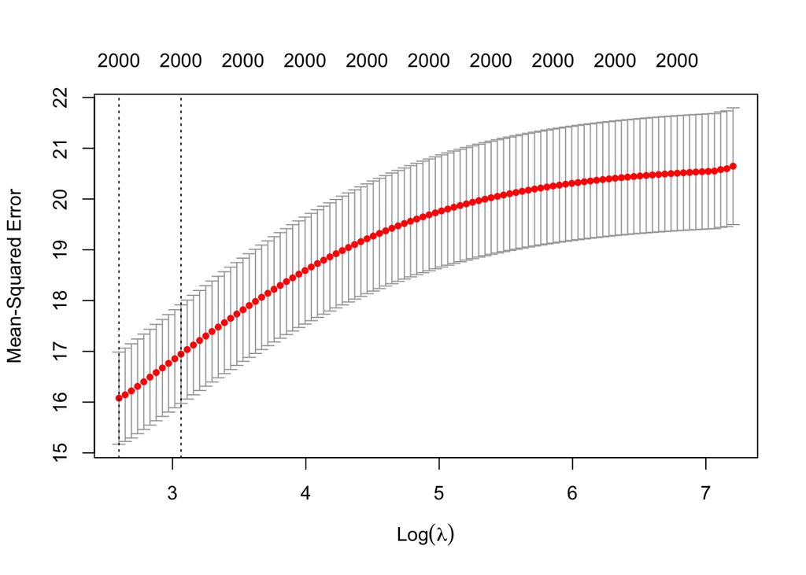

```r
cv.out1=cv.glmnet(xtr,ytr,alpha=0,nfolds=6)
plot(cv.out1)
```

```r
cat("Lambda with smallest CV Error for ridge",
cv.out1$lambda[which.min(cv.out1$cvm)],fill=TRUE)
```

```
## Lambda with smallest CV Error for ridge 13.44473
```

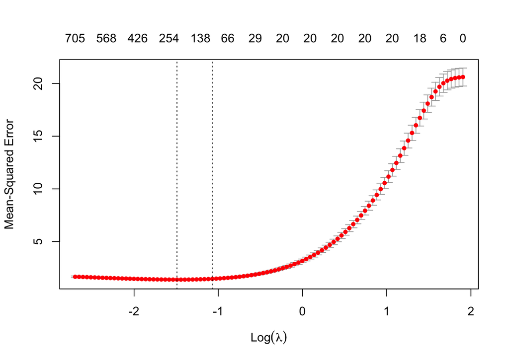

```r
cv.out2=cv.glmnet(xtr,ytr,alpha=0.2,nfolds=6)
plot(cv.out2)
```

```r
cat("Lambda with smallest CV Error for alpha=0.2 ",
cv.out2$lambda[which.min(cv.out2$cvm)],fill=TRUE)
```

```
## Lambda with smallest CV Error for alpha=0.2  0.2253069
```

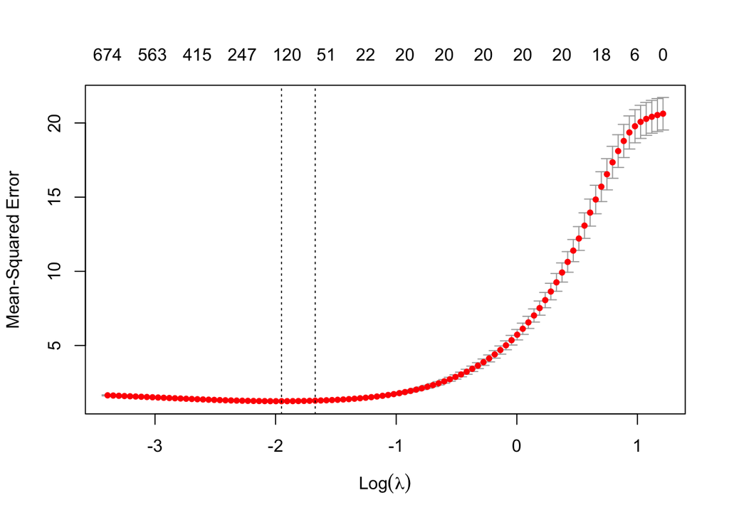

```r
cv.out3=cv.glmnet(xtr,ytr,alpha=0.4,nfolds=6)
plot(cv.out3)
```

```r
cat("Lambda with smallest CV Error for alpha=0.4",
cv.out3$lambda[which.min(cv.out3$cvm)],fill=TRUE)
```

```
## Lambda with smallest CV Error for alpha=0.4 0.1421526
```

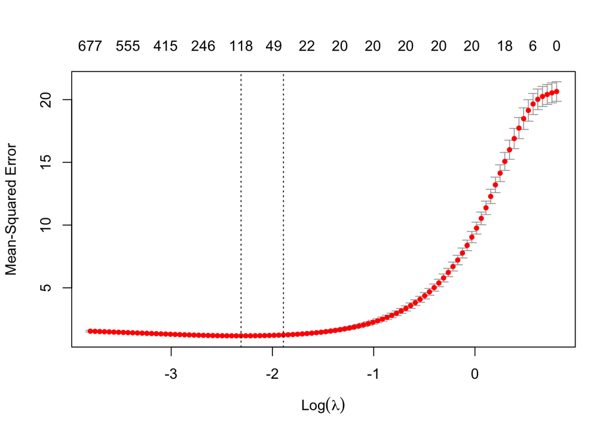

```r
cv.out4=cv.glmnet(xtr,ytr,alpha=0.6,nfolds=6)
plot(cv.out4)
```

```r
cat("Lambda with smallest CV Error for alpha=0.6",
cv.out4$lambda[which.min(cv.out4$cvm)],fill=TRUE)
```

```
## Lambda with smallest CV Error for alpha=0.6 0.09928084
```

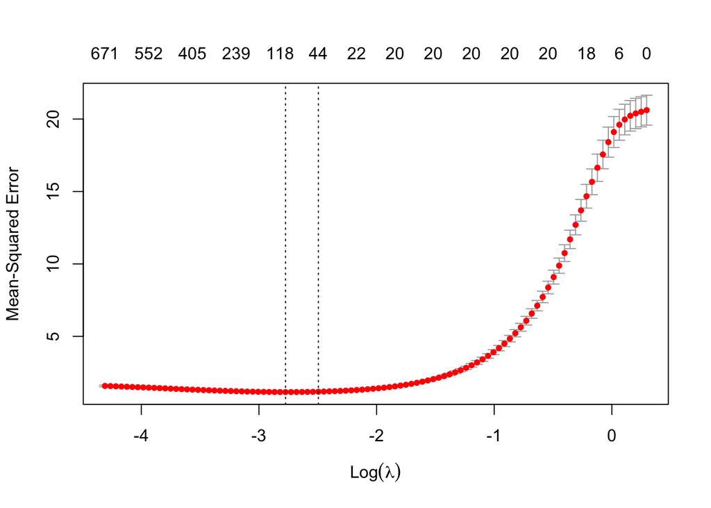

```r
cv.out5=cv.glmnet(xtr,ytr,alpha=1,nfolds=6)
plot(cv.out5)
```

```r
cat("Lambda with smallest CV Error for lasso",
cv.out5$lambda[which.min(cv.out5$cvm)],fill=TRUE)
```

```
## Lambda with smallest CV Error for lasso 0.0624049
```